# Pandas Tutorial

###### a.Group by Example with and without index

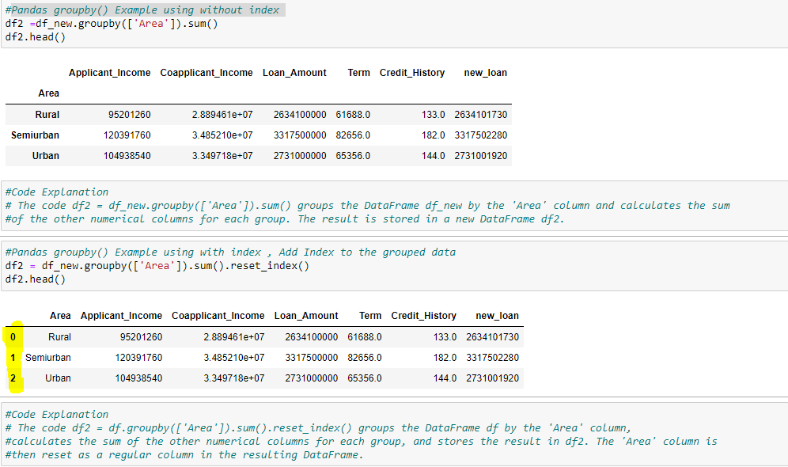

###### b.Pandas groupby() on Two or More Columns

Most of the time we would need to perform groupby on multiple columns of DataFrame, you can do this by passing a list of column labels you wanted to perform group by on.

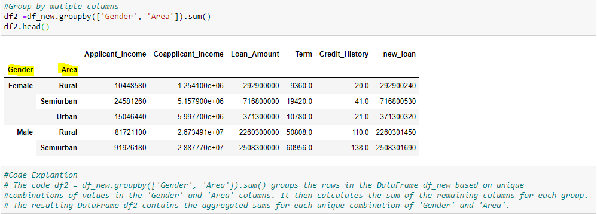

###### c.Sort groupby() result by Group Key

```python
# By default groupby() function sorts results by group key hence it will take additional time,
# if you have a performance issue and don’t want to sort the group by the result, you can turn this off by using the
# sort=False param.
```

###### c.Group by using count

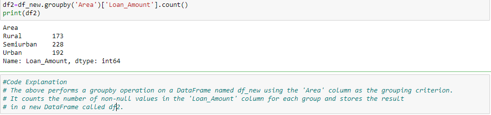

###### d. GroupBy & Sort Within Groups

```python
# Let'explore the example in from the loans dataset
```

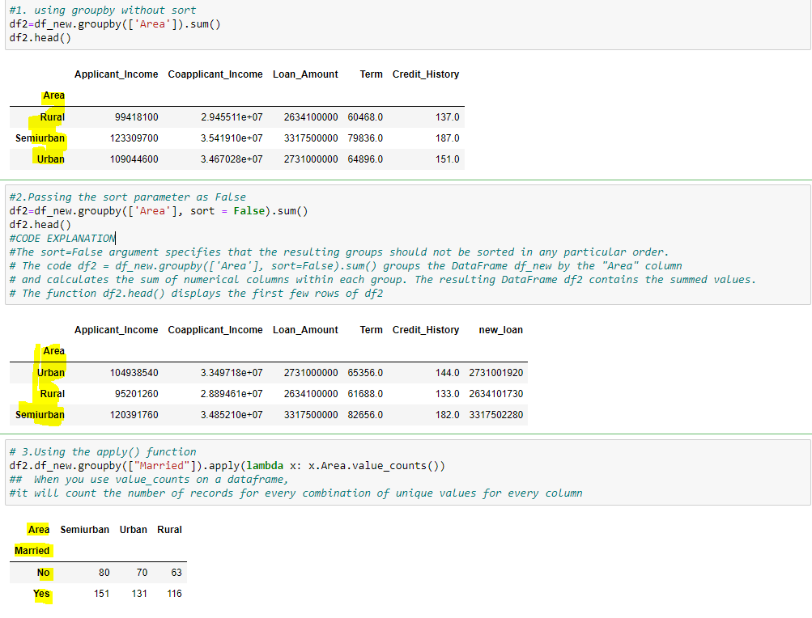

```python
#code explanation

# The code df.groupby(["Married"]).apply(lambda x: x.Area.value_counts()) groups the DataFrame df by
# the "Married" column and applies a lambda function to each group. The lambda function counts the occurrences of each
# unique value in the "Area" column within that group.
# The result is a DataFrame or Series showing the counts of unique "Area" values for each group.
```

#### 6.Data Types and Missing Values

###### Data Types

We can check the datatype of dataframe and columns in the following ways

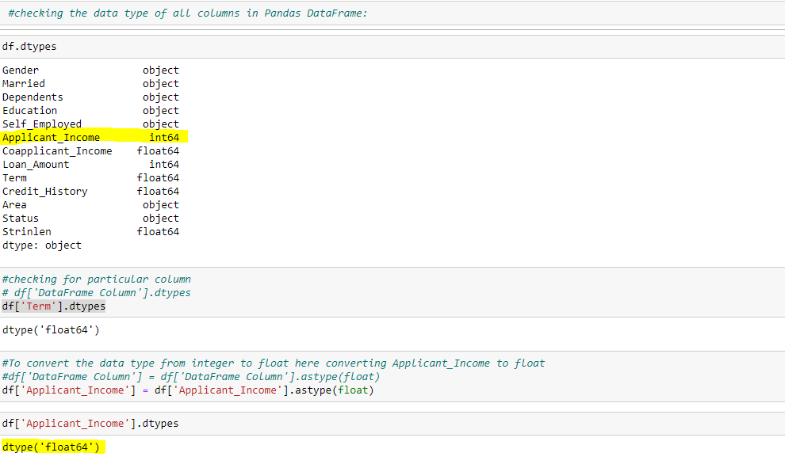

##### Missing Values

Pandas treat None and NaN as essentially interchangeable for indicating missing or null values. To facilitate this convention, there are several useful functions for detecting, removing, and replacing null values in Pandas DataFrame :

1.isnull()

2.notnull()

3.dropna()

4.fillna()

5.replace()

###### 1.isnull()

“isnull()” function to find out all the fields which have missing values. This will return True if a field has missing values and false if the field does not have missing values.

Now filtering out the columns from the original data frame by data type. By using “dtypes” function and equality operator you can get which columns are objects

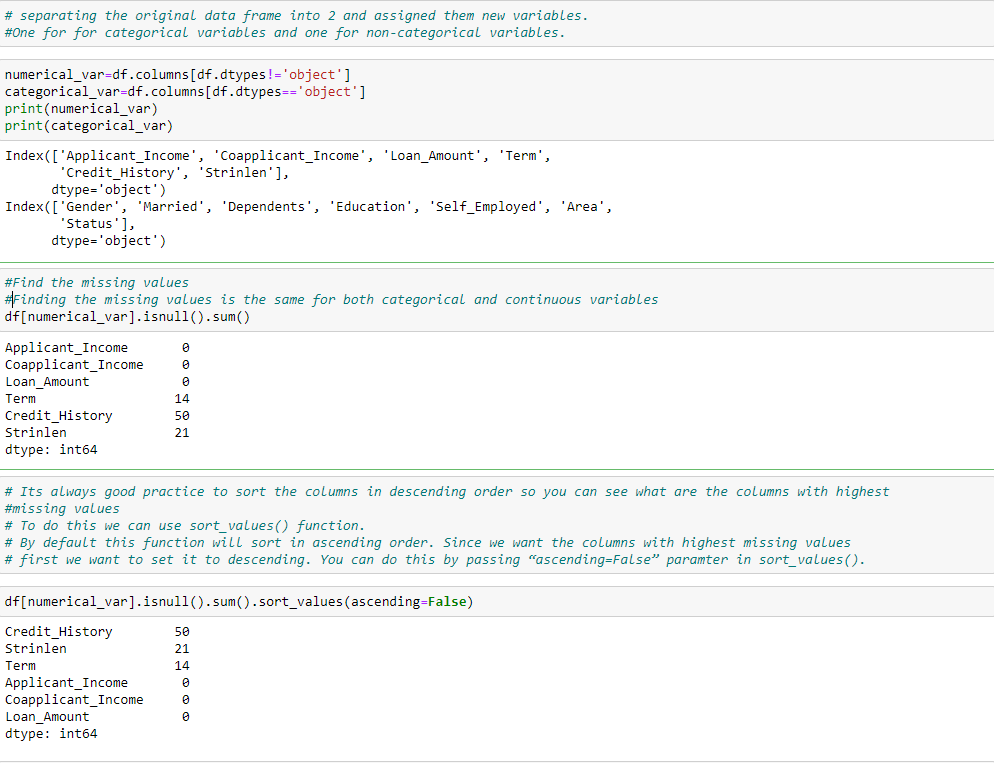

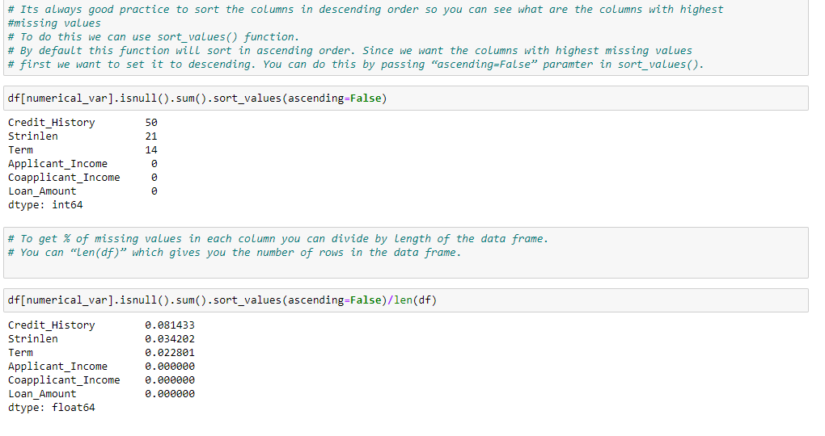